# Lake Okeechobee and Caloosahatchee River Estuary Conditions

Updated 2021-03-29 17:16:44

## Lake Okeechobee

### Stage Elevation

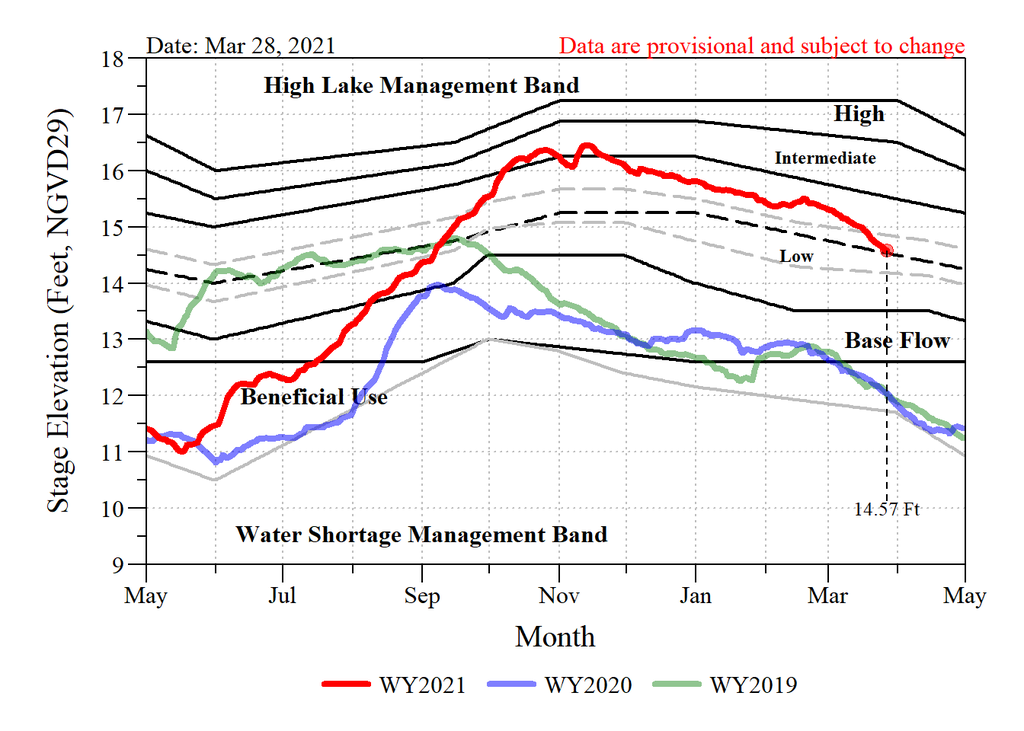

Lake Okeechobee daily average stage elevation for water year 2021 (WY2021) relative to the last two water years (red line) relative to the Lake Okeechobee Regulation Schedule (LORS) .

Data are provisional and subject to change.

| Stage and recession rates this time for the last three water years Date (Month-Day) | Stage and recession rates this time for the last three water years Water Year | Stage and recession rates this time for the last three water years Stage (ft, NGVD29) | Stage and recession rates this time for the last three water years 7-Day Recession Rate (ft 7-d⁻¹) | Stage and recession rates this time for the last three water years 30-Day Recession Rate (ft 30-d⁻¹) |
| --- | --- | --- | --- | --- |
| 03-27 | 2019 | 12.00 | -0.21 | -0.79 |
| 03-26 | 2020 | 12.05 | -0.24 | -0.70 |
| 03-27 | 2021 | 14.57 | -0.22 | -0.81 |

- As of 03/27/2021 the mean stage elevation in Lake Okeechobee is within the Operational Low Sub- Management Band at a stage elevation of 14.57 feet (NGVD29).

### Regional Rainfall

| Weekly rainfall totals along the Caloosahatchee River Mointoring Location | Weekly rainfall totals along the Caloosahatchee River Weekly Rainfall Total (inches) 1 |
| --- | --- |
| S79 (WP Franklin) | 0 |
| S78 (Ortona) | 0 |
| S77 (Moore Haven) | 0 |

1 Based on data from 03/23/2021 - 03/30/2021

### Relative Algae Condition

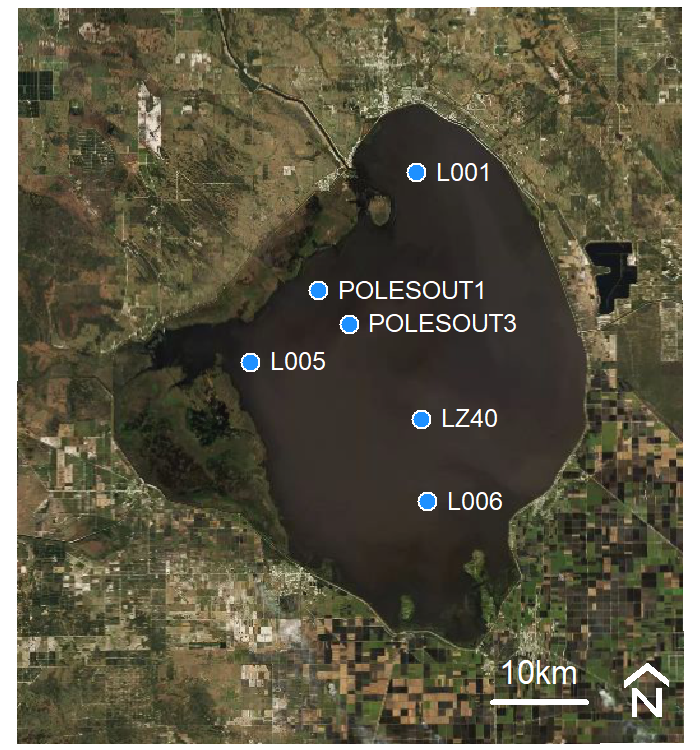

Sonde monitoring locations within Lake Okeechobee conducted by SFWMD.

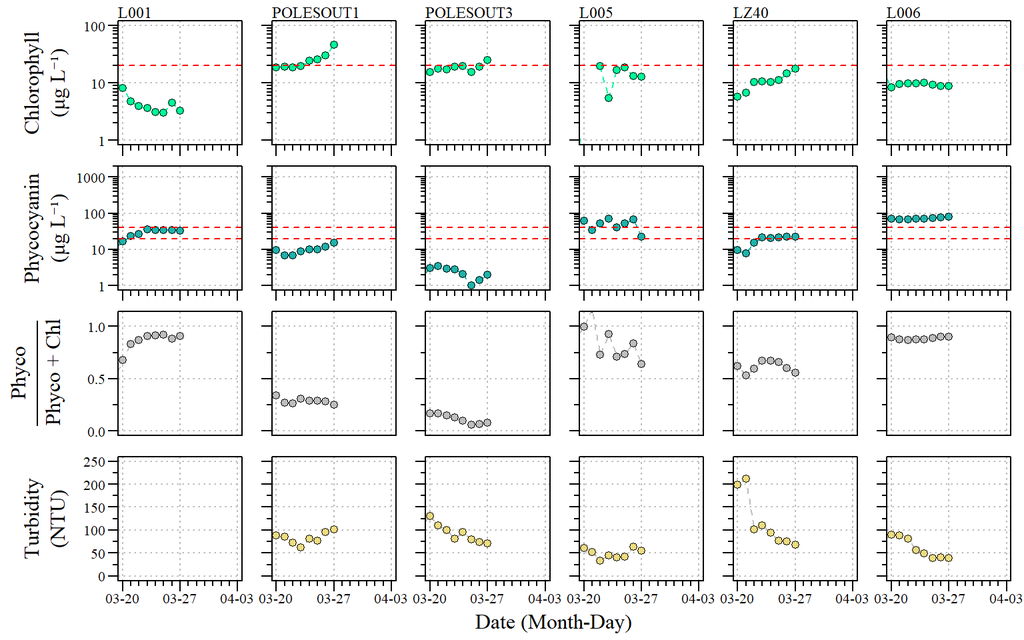

Data are provisional and subject to change.

- Cotterill et al (2019) Phycocyanin sensors as an early warning system for cyanobacteria blooms concentrations: a case study in the Rotorua lakes. New Zealand Journal of Marine and Freshwater Research 53:555–570.
- Macário et al (2015) New insights towards the establishment of phycocyanin concentration thresholds considering species-specific variability of bloom-forming cyanobacteria. Hydrobiologia 757:155–165.

[output not shown]

1 Based on data from 03/23/2021 - 03/30/2021